# Movement Class Prediction

Ryan Whitt

June 4, 2016

### Movement Classification Prediction

#### Using movement data collected from personal activity devices, the goal of this analysis is to precict which of 5 classifications an exercise falls into based on the associated sensor readings. The data for this is available at http://groupware.les.inf.puc-rio.br/har

1. Load Libraries

```r
library(reshape2)
library(ggplot2)
library(dplyr)
library(car)
library(caret)
library(doParallel)
library(randomForest)
library(corrplot)
```

2. Read in full training and validation data sets

```r
train <- read.csv("pml-training.csv", header=T, na.strings=c("","NA"))
validation <- read.csv("pml-testing.csv", header=T, na.strings=c("","NA"))
```

3. Evaluate dataset for missing data using missingness map created with ggplot

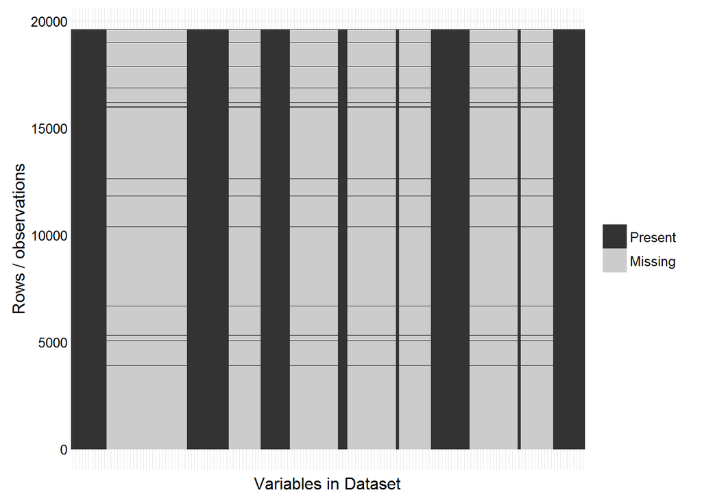

```r
ggplot_missing <- function(x){

  x %>%
    is.na %>%
    melt %>%
    ggplot(data = .,
           aes(x = Var2,
               y = Var1)) +
    geom_raster(aes(fill = value)) +
    scale_fill_grey(name = "",
                    labels = c("Present","Missing")) +
    theme_minimal() +
    theme(axis.text.x  = element_blank()) +
    #theme(axis.text.x  = element_text(angle=45, vjust=0.5)) +
    labs(x = "Variables in Dataset",
         y = "Rows / observations")
}

ggplot_missing(train)
```

4. We see a large amount of missing data. Upon examining the dataset, we also see several variables not important to classification prediction like userids and timestamps. We wiil remove obviously unimportant variables and any variables with >50% NA values.

```r
#remove all features with > 50% NA observations
train1 <- train[ , colSums(is.na(train)) < nrow(train)*.5]
valid1 <- validation[ , colSums(is.na(validation)) < nrow(validation)*.5]

#remove time and indiviudal classifiers for generalizability
train1 <- train1[,-c(1:7)]
valid1 <- valid1[,-c(1:7)]
```

5. Next it’s a good idea to examine data for multi-collinearity, we can do this using a correlation matrix plot from the corrplot package.

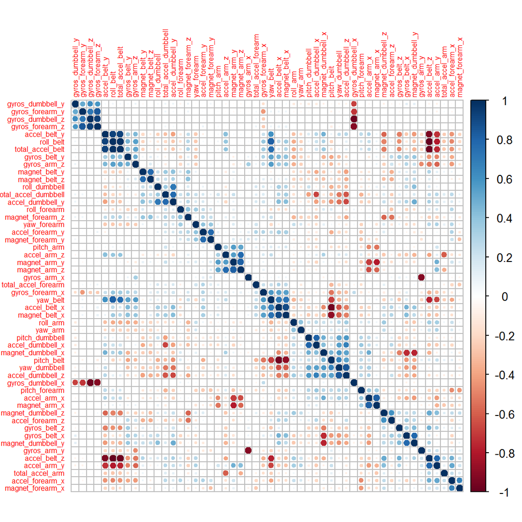

```r
corrplot(cor(train1[,-ncol(train1)]), order = "hclust", tl.cex=0.5)
```

6. Since we see a resonable number of colinear variables, we should select a model robsut to this. In this instance, we will use Random Forest. Next we can create training and testing sub-sets from the original training data for cross-validation.

```r
set.seed(5630)
part <- createDataPartition(y=train1$classe,p=0.5,list=FALSE)
training <- train1[part,]
testing <- train1[-part,]
```

7. Next we will create the Random Forest Model and utilize multiple CPU cores to speed up processing

```r
cluster <- makeCluster(detectCores() - 4)
registerDoParallel(cluster)
fit <- train(classe~.,data=training,method="rf", prox=TRUE, importance = TRUE, ntree = 300, allowParallel = TRUE)
stopCluster(cluster)
```

8. In viewing the results and most important variables, we a very high classification accuracy rate of >98%. We will confirm these results by validating out model against out of sample test data.

```r
fit
```

```
## Random Forest
##
## 9812 samples
##   52 predictor
##    5 classes: 'A', 'B', 'C', 'D', 'E'
##
## No pre-processing
## Resampling: Bootstrapped (25 reps)
## Summary of sample sizes: 9812, 9812, 9812, 9812, 9812, 9812, ...
## Resampling results across tuning parameters:
##
##   mtry  Accuracy   Kappa
##    2    0.9822823  0.9775773
##   27    0.9810714  0.9760450
##   52    0.9707378  0.9629654
##
## Accuracy was used to select the optimal model using  the largest value.
## The final value used for the model was mtry = 2.
```

```r
varImp(fit)
```

```
## rf variable importance
##
##   variables are sorted by maximum importance across the classes
##   only 20 most important variables shown (out of 52)
##
##                       A      B     C     D     E
## pitch_belt        63.60 100.00 51.08 67.75 66.42
## yaw_belt          77.07  80.82 62.66 97.74 44.67
## magnet_dumbbell_z 68.92  66.00 76.74 60.84 57.84
## magnet_dumbbell_y 49.95  52.19 76.19 49.01 37.68
## roll_belt         45.37  73.10 61.27 61.19 50.73
## roll_arm          39.13  66.21 55.87 52.50 45.58
## magnet_dumbbell_x 35.21  42.98 58.99 34.24 33.59
## accel_belt_z      38.48  58.75 51.06 43.80 38.46
## magnet_belt_x     13.95  56.40 39.06 24.75 47.67
## accel_dumbbell_y  37.97  55.83 49.07 51.28 45.81
## yaw_arm           37.80  50.67 46.73 55.35 37.47
## magnet_belt_y     38.82  47.07 53.73 44.50 39.18
## roll_dumbbell     24.12  40.25 53.52 42.77 34.16
## magnet_belt_z     38.16  50.36 43.34 53.38 37.10
## gyros_forearm_y   18.34  52.94 36.31 31.67 35.96
## gyros_belt_z      27.58  52.76 44.81 48.51 40.43
## pitch_forearm     41.41  45.16 43.14 52.67 38.79
## accel_forearm_z   25.74  52.01 47.32 38.32 39.26
## gyros_dumbbell_y  32.34  45.29 48.98 40.35 34.95
## gyros_dumbbell_x  19.98  48.33 29.76 32.66 23.27
```

9. Upon Cross-Validating the results against the test set, we see equally good performance with ~98.8% accuracy. We would estimate a roughly 1.2% miss-classification rate.

```r
confusionMatrix(testing$classe, predict(fit, testing))
```

```
## Confusion Matrix and Statistics
##
##           Reference
## Prediction    A    B    C    D    E
##          A 2780    4    0    0    6
##          B   21 1873    4    0    0
##          C    0   20 1687    4    0
##          D    0    0   34 1566    8
##          E    0    0    9    6 1788
##
## Overall Statistics
##
##                Accuracy : 0.9882
##                  95% CI : (0.9858, 0.9902)
##     No Information Rate : 0.2855
##     P-Value [Acc > NIR] : < 2.2e-16
##
##                   Kappa : 0.985
##  Mcnemar's Test P-Value : NA
##
## Statistics by Class:
##
##                      Class: A Class: B Class: C Class: D Class: E
## Sensitivity            0.9925   0.9873   0.9729   0.9937   0.9922
## Specificity            0.9986   0.9968   0.9970   0.9949   0.9981
## Pos Pred Value         0.9964   0.9868   0.9860   0.9739   0.9917
## Neg Pred Value         0.9970   0.9970   0.9942   0.9988   0.9983
## Prevalence             0.2855   0.1934   0.1768   0.1607   0.1837
## Detection Rate         0.2834   0.1909   0.1720   0.1596   0.1823
## Detection Prevalence   0.2844   0.1935   0.1744   0.1639   0.1838
## Balanced Accuracy      0.9955   0.9921   0.9850   0.9943   0.9952
```